# 68806_EX2_PMmodel

YBD

2016 M11 15

## ET Estimation using Penman-Montieth Equation

This file shows the solution to Ex.2 for the P-M model of ET estimation and some of its adjustments

```
##          date           day            month             year
##  2000-10-01:   1   Min.   : 1.00   Min.   : 1.000   Min.   :2000
##  2000-10-02:   1   1st Qu.: 8.00   1st Qu.: 4.000   1st Qu.:2002
##  2000-10-03:   1   Median :16.00   Median : 7.000   Median :2005
##  2000-10-04:   1   Mean   :15.73   Mean   : 6.523   Mean   :2005
##  2000-10-05:   1   3rd Qu.:23.00   3rd Qu.:10.000   3rd Qu.:2007
##  2000-10-06:   1   Max.   :31.00   Max.   :12.000   Max.   :2009
##  (Other)   :3281
##        wy             yd             wyd             tavg
##  Min.   :2001   Min.   :  1.0   Min.   :  1.0   Min.   : 7.971
##  1st Qu.:2003   1st Qu.: 92.0   1st Qu.: 92.0   1st Qu.:13.946
##  Median :2005   Median :183.0   Median :182.0   Median :16.058
##  Mean   :2005   Mean   :183.1   Mean   :182.6   Mean   :16.010
##  3rd Qu.:2007   3rd Qu.:274.5   3rd Qu.:274.0   3rd Qu.:18.112
##  Max.   :2009   Max.   :366.0   Max.   :366.0   Max.   :27.871
##
##       vpd               rnet                gs                ga
##  Min.   :  28.87   Min.   :   16098   Min.   :0.00020   Min.   :6.445
##  1st Qu.: 353.95   1st Qu.: 4939730   1st Qu.:0.09279   1st Qu.:6.484
##  Median : 452.87   Median : 6635905   Median :0.55273   Median :6.510
##  Mean   : 478.49   Mean   : 7186978   Mean   :0.50487   Mean   :6.518
##  3rd Qu.: 581.88   3rd Qu.: 9526275   3rd Qu.:0.78075   3rd Qu.:6.557
##  Max.   :1438.88   Max.   :13683164   Max.   :1.71005   Max.   :6.594
##
##       lai             trans              swp             precip
##  Min.   :0.4311   Min.   :0.00000   Min.   :-7.000   Min.   :  0.000
##  1st Qu.:0.5594   1st Qu.:0.01219   1st Qu.:-6.646   1st Qu.:  0.000
##  Median :0.7004   Median :0.33409   Median :-0.694   Median :  0.000
##  Mean   :0.7127   Mean   :0.41035   Mean   :-2.873   Mean   :  1.433
##  3rd Qu.:0.8540   3rd Qu.:0.63033   3rd Qu.:-0.500   3rd Qu.:  0.000
##  Max.   :1.1613   Max.   :2.24093   Max.   :-0.500   Max.   :129.540
##
```

# calculate daylight hours in Jerusalem to be used as input to P-M function

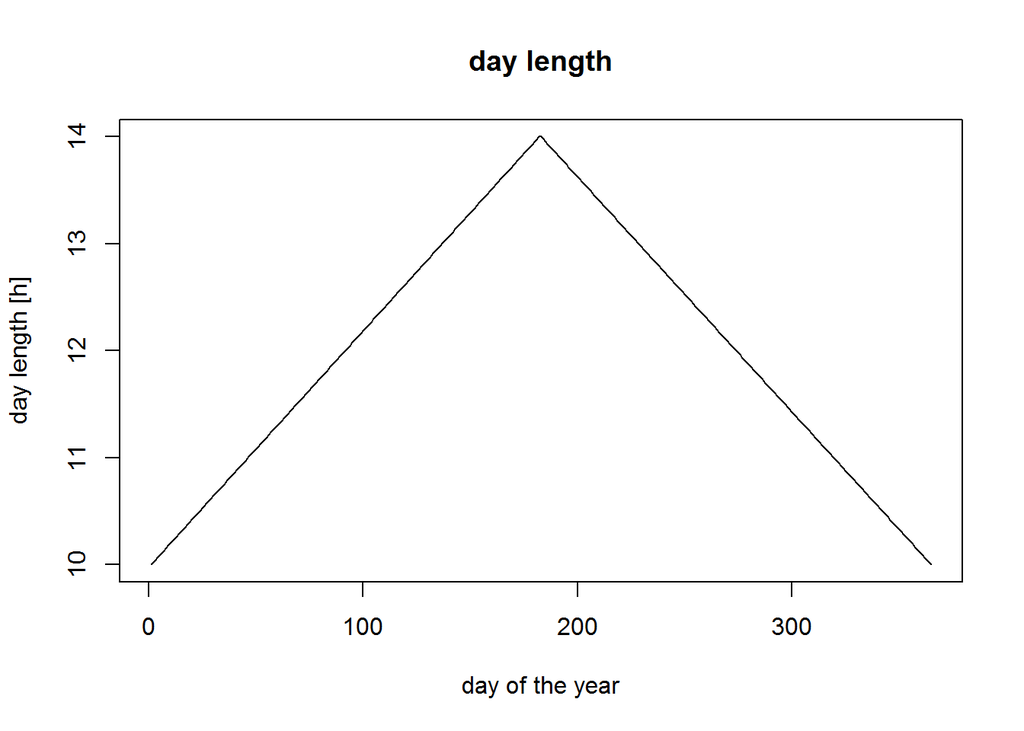

calculate ET using the Penman-Montieth equation of Naomi

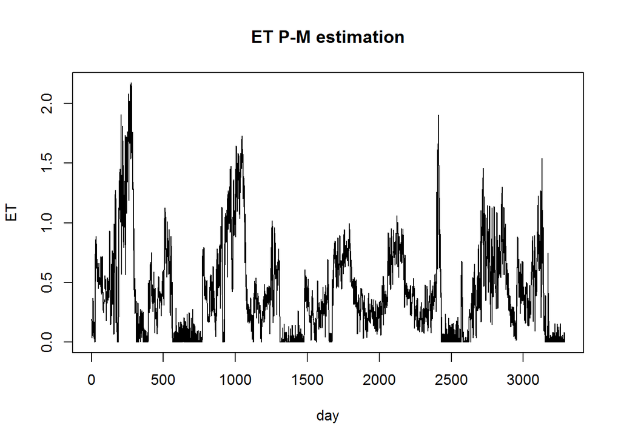

```r
#' Penman Montieth Equation
#'
#' THis function computer evapotranspiration based on radiation, conductance etc
#'

#' @param        Tair    (deg C) air temperature
#' @param    vpd     (Pa)    vapour pressure deficit
#' @param     Rnet    (j/m2/day)      net radiation
#' @param     gs      (s/mm)  surface conductance
#' @param     ga      (s/mm)  aerodynamic conductance
#' @param     CP  =      1010.0 (J/kg*K) specific heat of air
#' @param    Pair = 101325 (Pa)
#' @author Naomi
#' @return Evapotranspiration (mm/day)


penman_montieth =
function(Tair, vpd, Rnet, gs,ga, dayl, CP=1010, Pair=101325) {

  #       Internal Variables
  #
  #       rho     (kg/m3)         density of air
  #       CP      (K/jg/degC)     specific heat of air
  #       lhvap   (J/kg)          latent heat of vapourization H20
  #       s       (Pa/degC)       slope of sat vpd vs T curve
  #       rs      (s/m)   surface resistance
  #       ra      (s/m)   aerodynamic resistance


  # convert Rnet to daytime value in j/m2/s
  Rnet = Rnet / (60*60*dayl)

  # convert conductance to resistance and change units
  rs = 1000.0/gs
  ra = 1000.0/ga

  # Assign tk (Kelvins)
  tk = Tair + 273.15

  #       Density of air (rho) as a fn. of air temp.
  rho = 1.292 * ( 0.00428 * Tair )

  #       Latent heat of vapourization as a fn. of Tair.
  lhvap = 2.5023e6 - 2430.54 * Tair

  #       Temperature offsets for slope estimates
  dt = 0.2
  t1 = Tair + dt
  t2 = Tair - dt

  #       Saturation vapour pressures at t1 and t2(Pa)
  pvs1 = 610.7 * exp(17.38 * t1 / ( 239.0 + t1))
  pvs2 = 610.7 * exp(17.38 * t2 / ( 239.0 + t2))

  #       Slope of pvs vs T curve at Tair (Pa/deg C)
  s = ( pvs1 -   pvs2 ) / ( t1 -  t2 )

  #       Calculate gamma
  gamma = CP * Pair / ( lhvap )


  #       Evaporation in W/m2
  et = ((s*Rnet) + (rho*CP*vpd/ra)) / (gamma*(1.0 + rs/ra) +s)


  #       mH20/s = W/m2 * 1kgH20/lhvap J * 1m3H20/1000kGH20
  ewater = ( et/ ( lhvap * 1000 ))

  # mmH20/day
  ewater.day = ewater * dayl*60*60 * 1000

  # return from your function
  ewater.day
}
```

Adjust gs values following simplistic assumptions in Naomi email if the temperature is above mean temperature, the maximum gs value is assigned if the temperature is below mean temperature, a zero value is assigned

```r
# this function modifies the gs value according to the Naomi's example

#' @param        Tair    (deg C) air temperature
#' @param     gs      (s/mm)  surface conductance
#' @author Yoav BD
#' @return new gs (s/mm)

modified_gs=
  function(gs, Tair){
  cond1=mean(Tair)
  maxgs=max(gs)
  # calculate ET
  newgs=ifelse (Tair >= cond1, maxgs, 0)
}
```

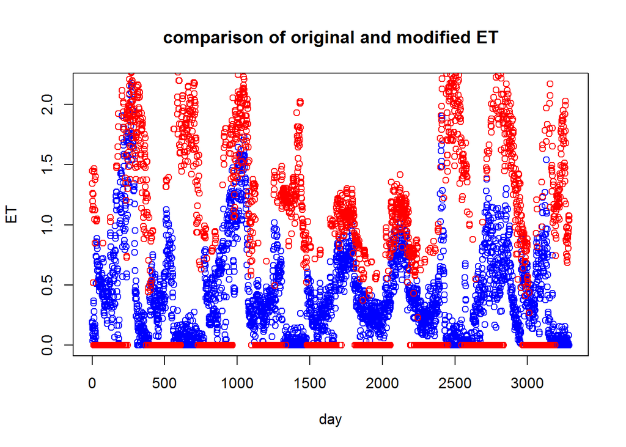

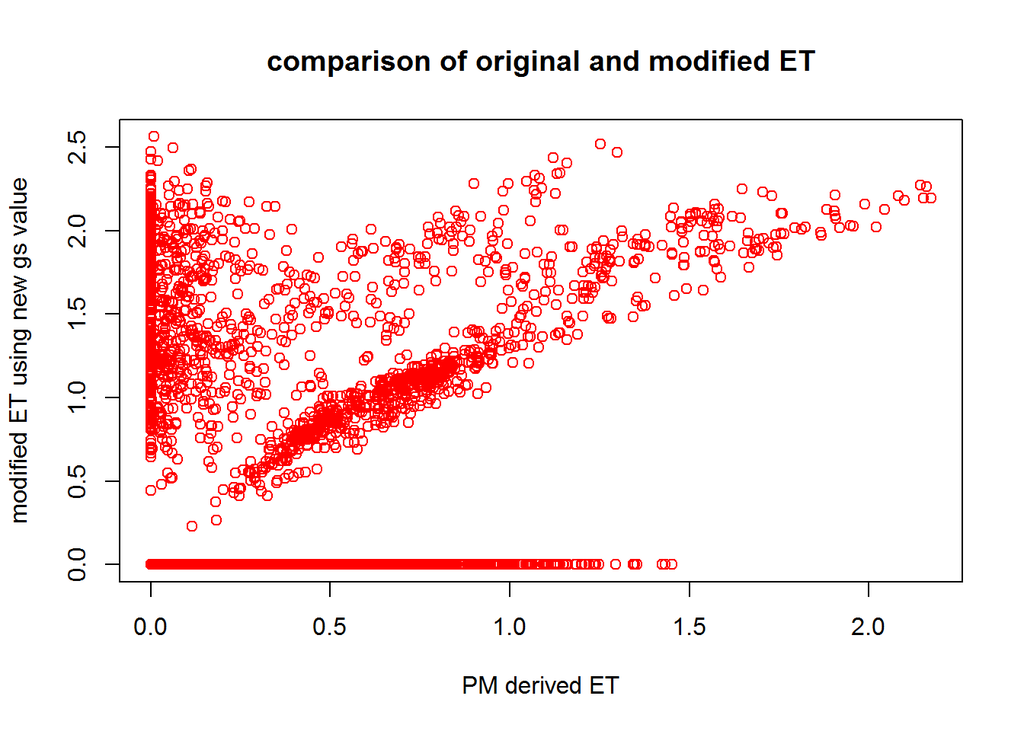

# adjust gs according to a second set of assumptions

gs is a multiple of maximum gs value multiplied by a vpd scaling factor and a linear gs-t relationship

```r
# Modify gs values:
# gs is defined by its max value, multiplied with relative Tair scale factor and scaled vpd

#' @param    Tair    (deg C) air temperature
#' @param    vpd     (Pa)    vapour pressure deficit
#' @param    gs      (s/mm)  surface conductance
#' @author Yoav BD
#' @return Evapotranspiration (mm/day)


modified_gs2 =
  function(Tair, vpd, gs) {
    # find max value of gs
    maxgs=max(gs)

    # parametrize a linear gs-t relationship
    xval=seq(from=min(Tair) , to=max(Tair), by=0.001 )
    yval=seq(from=0.8 , to=1, length.out =length(xval))
    gstfactor=rep(0,length(gs))
    for (ii in 1:length(gs)) {
      gstfactor[ii]=yval[match(Tair[ii],xval)]
    }

    # scale the vpd values
    scaledvpd=vpd/max(vpd)

    newgs=maxgs*scaledvpd*gstfactor
  }
```

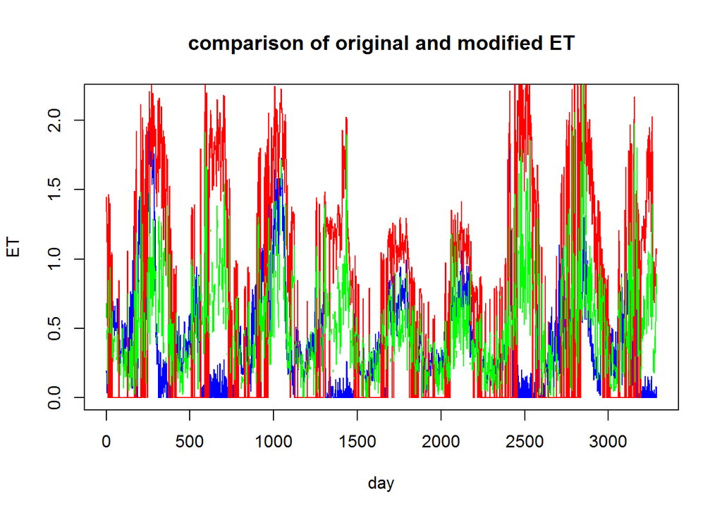

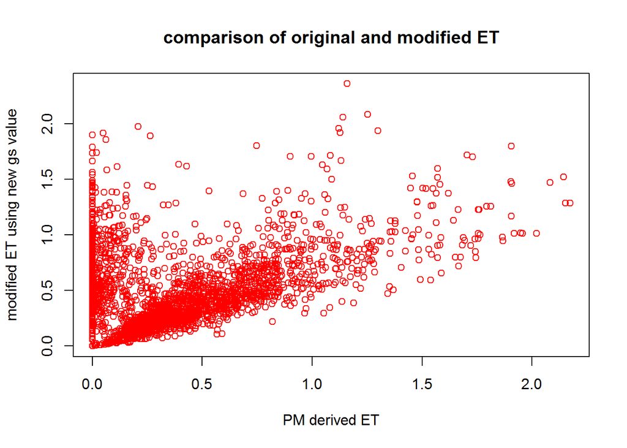

# sensitivity estimation

visually estimate the effect of several parameters of the PM function each variable is separately multiplied by a factor running from 0 to 2 with differences of 0.05 blue lines indicate factors smaller than 1, red lines indicate factor larger than 1, and black line indicates original estimation of ET values

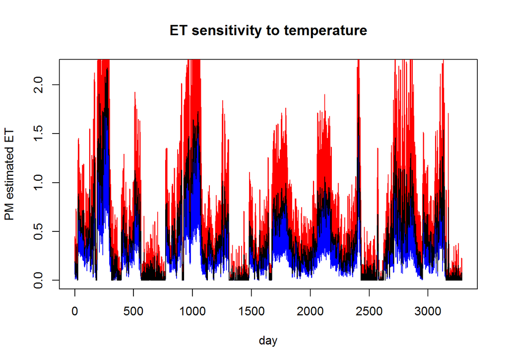

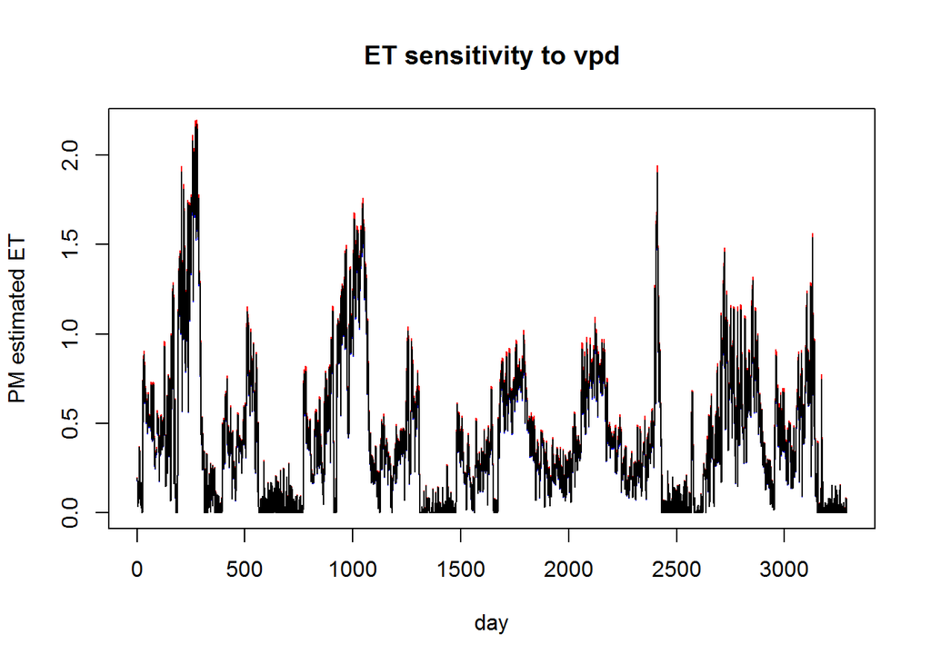

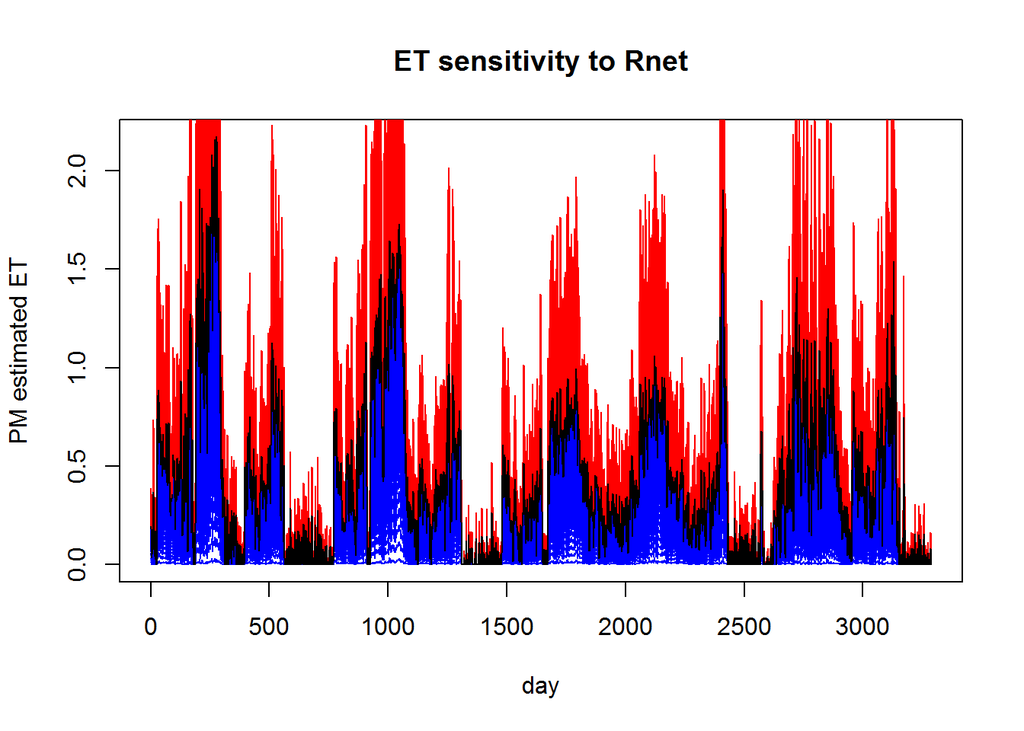

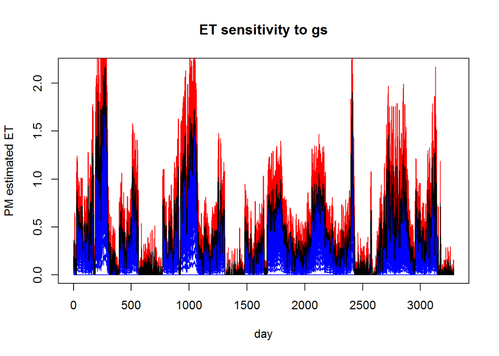

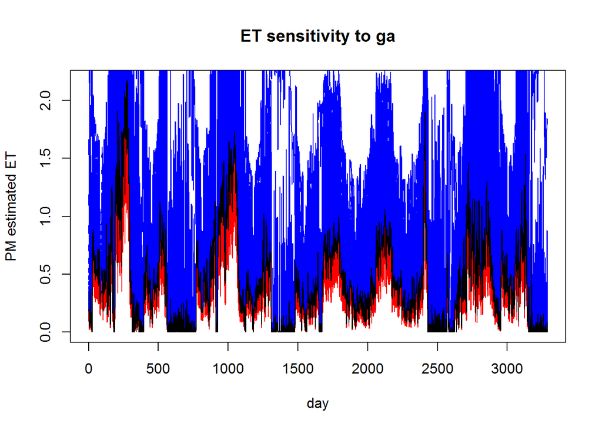

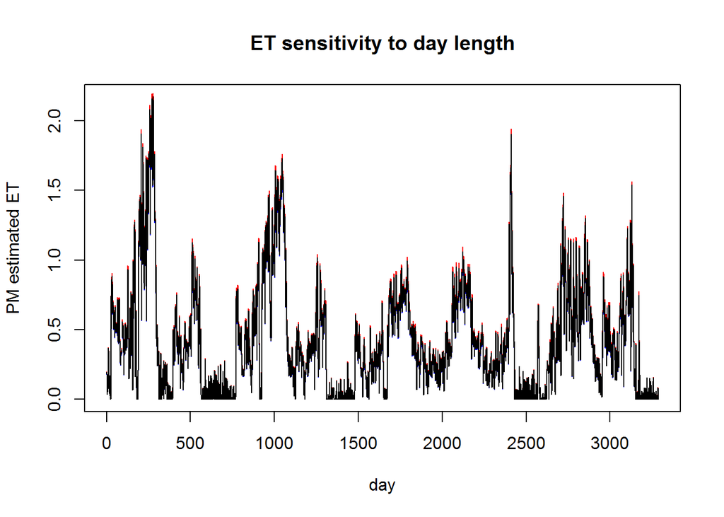

# Conclusions

the model appears to show high sensitivity to some of the inputs, but also demonstrates high resiliency to others vpd and day length have little effect on the PM estimation of ET Radiation and temperature show relatively high sensitivity, while gs shows relatively moderate impact ga shows inverse sensitivity, and increasing factors produce smaller ET values, highest values are obtained for the smallest factors, while increasing ga shows moderate impact on ET. this relationship is easily explained by the location of the ga term in the PM equation